# 03.1-Peve-sRNA-summary

## 5.2 Plot normalized data

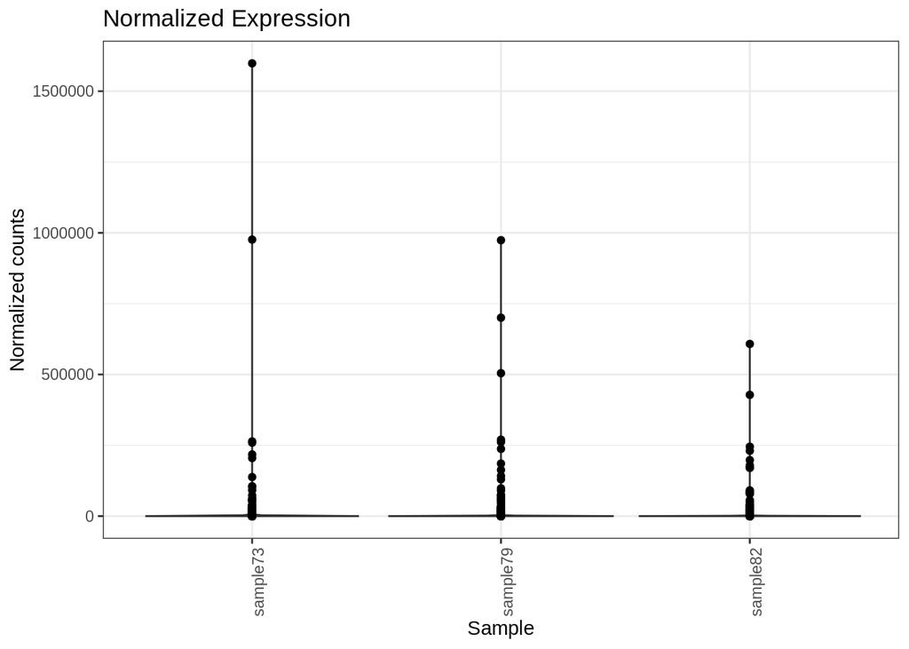

```r
Peve_counts_sRNA_norm_long <- Peve_counts_sRNA_norm %>%
  mutate(
    Gene_id = row.names(Peve_counts_sRNA_norm)
  ) %>%
  pivot_longer(-Gene_id)

Peve_counts_sRNA_norm_long %>%
  ggplot(., aes(x = name, y = value)) +
  geom_violin() +
  geom_point() +
  theme_bw() +
  theme(
    axis.text.x = element_text( angle = 90)
  ) +
  ylim(0, NA) +
  labs(
    title = "Normalized Expression",
    x = "Sample",
    y = "Normalized counts"
  )
```

## 5.3 Plot variance stabilized data

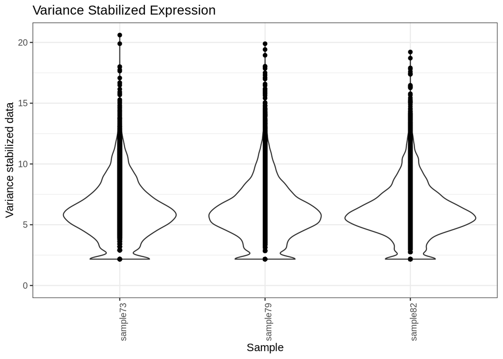

```r
Peve_counts_sRNA_vsd_long <- Peve_counts_sRNA_vsd %>%
  mutate(
    Gene_id = row.names(Peve_counts_sRNA_vsd)
  ) %>%
  pivot_longer(-Gene_id)

Peve_counts_sRNA_vsd_long %>%
  ggplot(., aes(x = name, y = value)) +
  geom_violin() +
  geom_point() +
  theme_bw() +
  theme(
    axis.text.x = element_text( angle = 90)
  ) +
  ylim(0, NA) +
  labs(
    title = "Variance Stabilized Expression",
    x = "Sample",
    y = "Variance stabilized data"
  )
```

## 5.4 Normalized expression levels

Plot histograms of the normalized expression levels in each sample

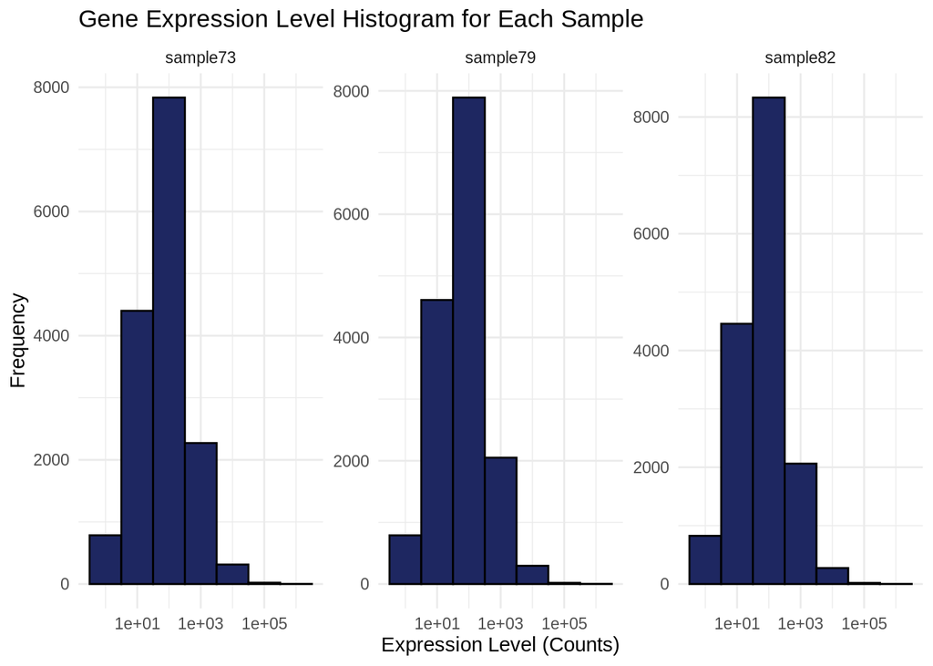

```r
# Melt the count matrix into long format
Peve_counts_norm_melted <- melt(Peve_counts_sRNA_norm, variable.name = "sample", value.name = "counts")

# Plot the expression level histograms for each sample
ggplot(Peve_counts_norm_melted, aes(x = counts)) +
  geom_histogram(binwidth = 1, fill = "#1E2761", color = "black") +
  scale_x_log10() +  # Optional: Log-transform the x-axis for better visualization
  facet_wrap(~sample, scales = "free_y") +
  labs(title = "Gene Expression Level Histogram for Each Sample",
       x = "Expression Level (Counts)",
       y = "Frequency") +
  theme_minimal()
```

## 5.5 Normalized transcript counts

Check the total number of transcripts in each sample – now that we’ve normalized the data these totals should be similar

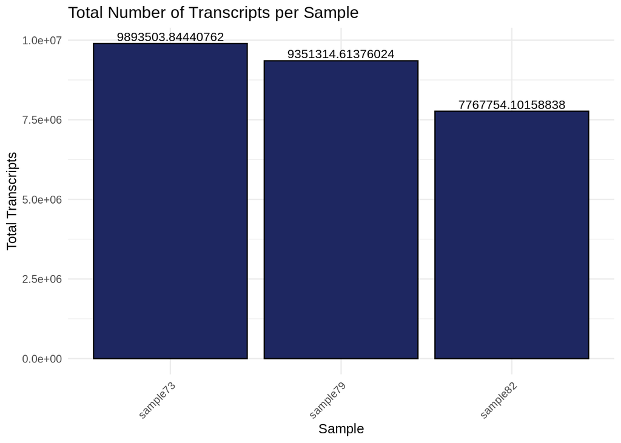

```r
# Calculate the total number of transcripts for each sample
total_transcripts_norm <- colSums(Peve_counts_sRNA_norm)

# Create a data frame for plotting
total_transcripts_norm_df <- data.frame(sample = names(total_transcripts_norm),
                                   totals = total_transcripts_norm)

# Plot the total number of transcripts for each sample
ggplot(total_transcripts_norm_df, aes(x = sample, y = totals)) +
  geom_bar(stat = "identity", fill = "#1E2761", color = "black") +
  geom_text(aes(label = totals), vjust = -0.3, size = 3.5) +
  labs(title = "Total Number of Transcripts per Sample",
       x = "Sample",
       y = "Total Transcripts") +
  theme_minimal() +
  theme(axis.text.x = element_text(angle = 45, hjust = 1))  # Rotate x-axis labels for readability
```

## 5.6 PCA of variance stabilized data

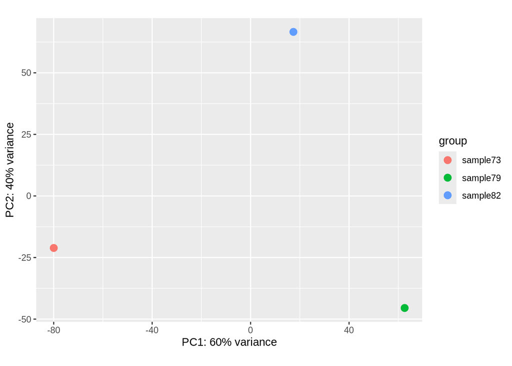

```r
plotPCA(vsd_Peve_sRNA, intgroup="Sample")
```

## 5.7 Sample clustering

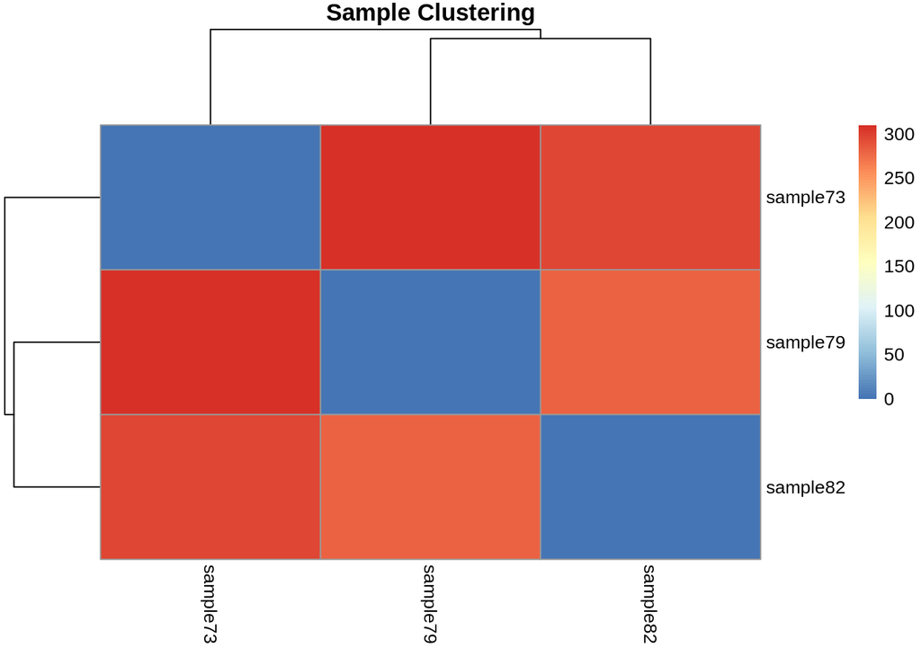

```r
sample_dists <- dist(t(assay(vsd_Peve_sRNA)))
pheatmap(as.matrix(sample_dists), clustering_distance_rows = "euclidean",
         clustering_distance_cols = "euclidean", main="Sample Clustering")
```

## 5.8 Heatmaps

Of most variable variance stabilized sRNA transcripts

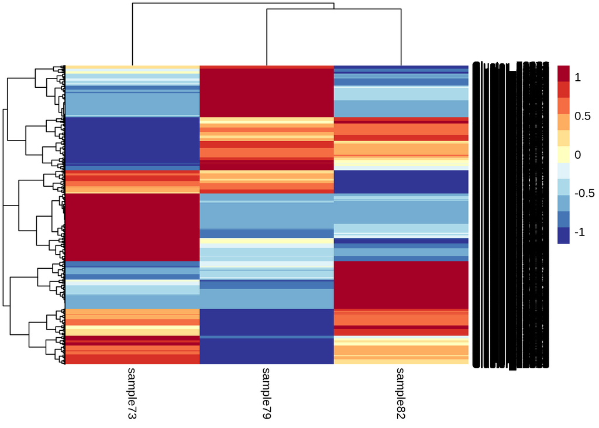

```r
# 75th quantile
heat_colors <- rev(brewer.pal(12, "RdYlBu"))
pheatmap(Peve_counts_sRNA_vsd_q75,
         cluster_rows = TRUE,
         cluster_cols = TRUE,
         show_rownames = TRUE,
         show_colnames = TRUE,
         color = heat_colors,
         scale="row")
```

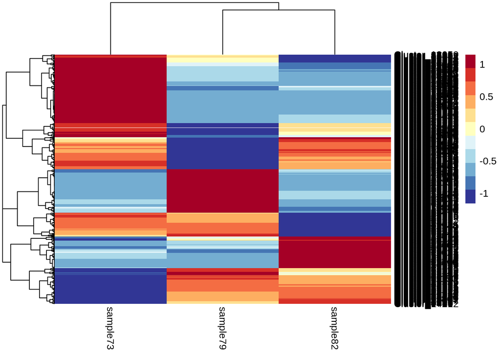

```r
# 95th quantile
pheatmap(Peve_counts_sRNA_vsd_q95,
         cluster_rows = TRUE,
         cluster_cols = TRUE,
         show_rownames = TRUE,
         show_colnames = TRUE,
         color = heat_colors,
         scale="row")
```

# 6 Normalized miRNA counts

## 6.1 Isolate normalized/vsd miRNA

```r
## Also written to use given miRNA names ##
# Peve_counts_sRNA_norm$Name <- rownames(Peve_counts_sRNA_norm)
# Peve_counts_miRNA_norm <- left_join(Peve_metadata_miRNA, Peve_counts_sRNA_norm, by = c("Name" = "Name")) %>%
#   column_to_rownames(var="given_miRNA_name") %>%
#   select(starts_with("sample"))
# write.table(Peve_counts_miRNA_norm, file = "../output/03.1-Peve-sRNA-summary/Peve_counts_miRNA_normalized.txt", sep = "\t", row.names = TRUE, col.names = TRUE,quote = FALSE)
#
# Peve_counts_sRNA_vsd$Name <- rownames(Peve_counts_sRNA_vsd)
# Peve_counts_miRNA_vsd <- left_join(Peve_metadata_miRNA, Peve_counts_sRNA_vsd, by = c("Name" = "Name")) %>%
#   column_to_rownames(var="given_miRNA_name") %>%
#   select(starts_with("sample"))
# write.table(Peve_counts_miRNA_vsd, file = "../output/03.1-Peve-sRNA-summary/Peve_counts_miRNA_variancestabilized.txt", sep = "\t", row.names = TRUE, col.names = TRUE,quote = FALSE)

## Use below until you have miRNA names ##
Peve_counts_sRNA_norm$Name <- rownames(Peve_counts_sRNA_norm)
Peve_counts_sRNA_vsd$Name <- rownames(Peve_counts_sRNA_vsd)

Peve_counts_miRNA_namesdf <- data.frame(Name = rownames(Peve_counts_miRNA))

Peve_counts_miRNA_norm <- left_join(Peve_counts_miRNA_namesdf, Peve_counts_sRNA_norm, by = c("Name" = "Name")) %>%
  column_to_rownames(var = "Name")
write.table(Peve_counts_miRNA_norm, file = "../output/03.1-Peve-sRNA-summary/Peve_counts_miRNA_normalized.txt", sep = "\t", row.names = TRUE, col.names = TRUE,quote = FALSE)

Peve_counts_miRNA_vsd <- left_join(Peve_counts_miRNA_namesdf, Peve_counts_sRNA_vsd, by = c("Name" = "Name")) %>%
  column_to_rownames(var = "Name")
write.table(Peve_counts_miRNA_vsd, file = "../output/03.1-Peve-sRNA-summary/Peve_counts_miRNA_variancestabilized.txt", sep = "\t", row.names = TRUE, col.names = TRUE,quote = FALSE)
```

## 6.2 Normalized expression levels

Plot histograms of the normalized expression levels in each sample

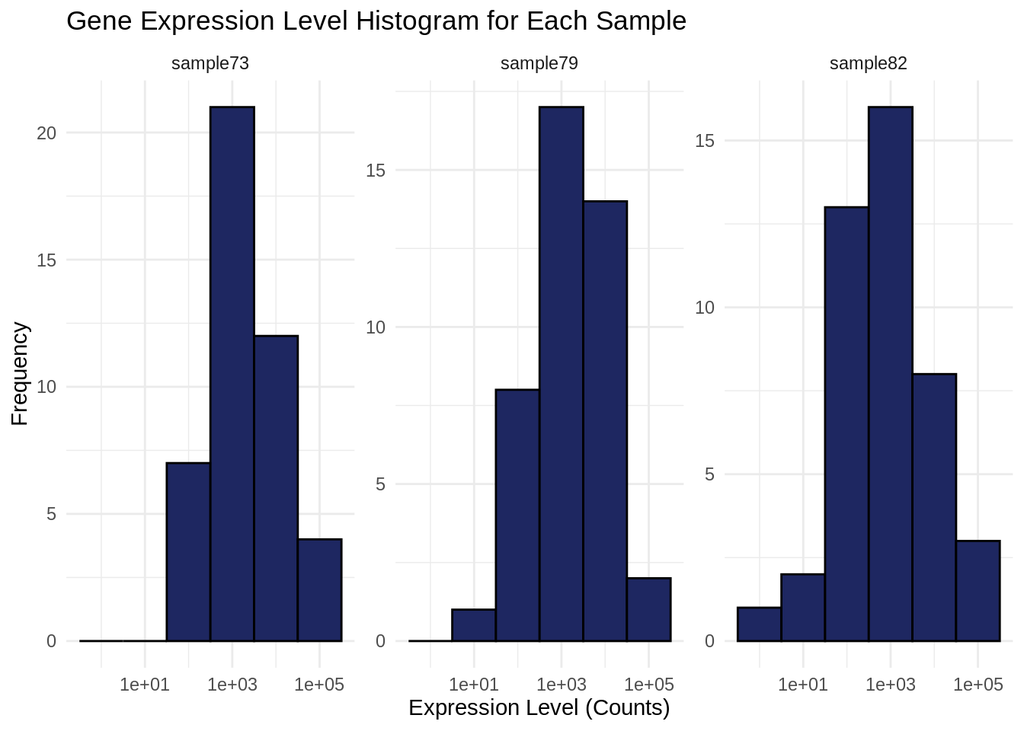

```r
# Melt the count matrix into long format
Peve_counts_miRNA_norm_melted <- melt(Peve_counts_miRNA_norm, variable.name = "sample", value.name = "counts")

# Plot the expression level histograms for each sample
ggplot(Peve_counts_miRNA_norm_melted, aes(x = counts)) +
  geom_histogram(binwidth = 1, fill = "#1E2761", color = "black") +
  scale_x_log10() +  # Optional: Log-transform the x-axis for better visualization
  facet_wrap(~sample, scales = "free_y") +
  labs(title = "Gene Expression Level Histogram for Each Sample",
       x = "Expression Level (Counts)",
       y = "Frequency") +
  theme_minimal()
```

## 6.3 Normalized transcript counts

Check the total number of transcripts in each sample – now that we’ve normalized the data these totals should be similar

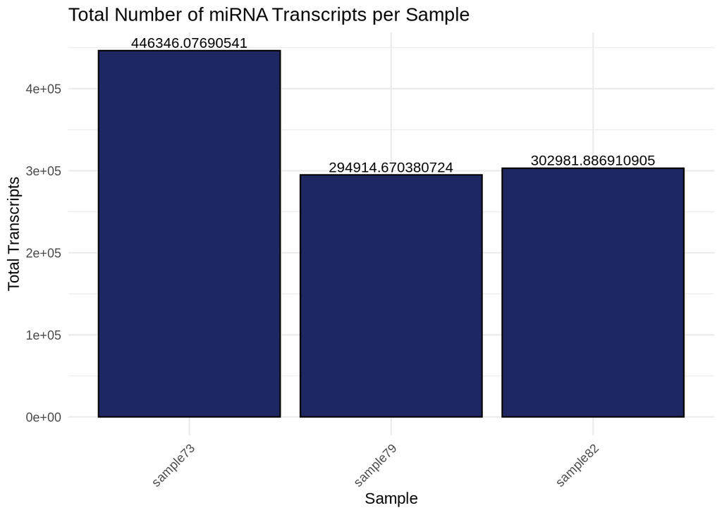

```r
# Calculate the total number of transcripts for each sample
total_transcripts_miRNA_norm <- colSums(Peve_counts_miRNA_norm)

# Create a data frame for plotting
total_transcripts_miRNA_norm_df <- data.frame(sample = names(total_transcripts_miRNA_norm),
                                   totals = total_transcripts_miRNA_norm)

# Plot the total number of transcripts for each sample
ggplot(total_transcripts_miRNA_norm_df, aes(x = sample, y = totals)) +
  geom_bar(stat = "identity", fill = "#1E2761", color = "black") +
  geom_text(aes(label = totals), vjust = -0.3, size = 3.5) +
  labs(title = "Total Number of miRNA Transcripts per Sample",
       x = "Sample",
       y = "Total Transcripts") +
  theme_minimal() +
  theme(axis.text.x = element_text(angle = 45, hjust = 1))  # Rotate x-axis labels for readability
```

## 6.4 Heatmap

Of all miRNAs

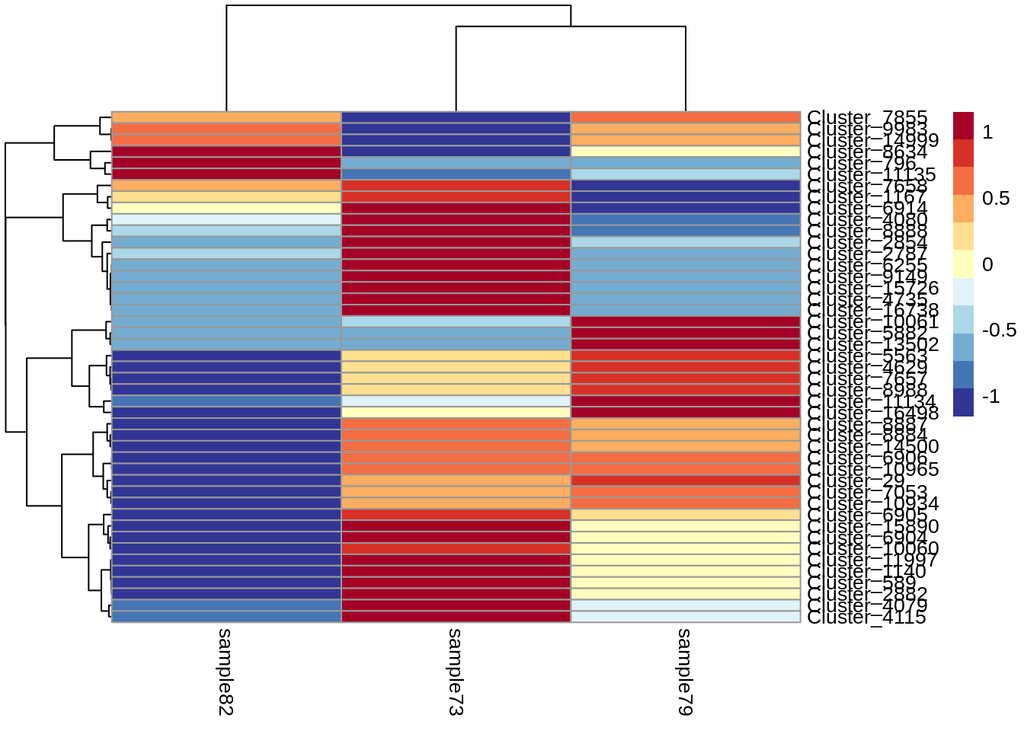

```r
heat_colors <- rev(brewer.pal(12, "RdYlBu"))
pheatmap(as.matrix(Peve_counts_miRNA_vsd[apply(Peve_counts_miRNA_vsd, 1, var) > 0, ]),
         cluster_rows = TRUE,
         cluster_cols = TRUE,
         show_rownames = TRUE,
         show_colnames = TRUE,
         color = heat_colors,
         scale="row")
```

# 7 Normalized siRNA counts

## 7.1 Isolate normalized/vsd siRNA

```r
Peve_counts_sRNA_norm$Name <- rownames(Peve_counts_sRNA_norm)
Peve_counts_sRNA_vsd$Name <- rownames(Peve_counts_sRNA_vsd)

Peve_counts_siRNA_namesdf <- data.frame(Name = rownames(Peve_counts_siRNA))

Peve_counts_siRNA_norm <- left_join(Peve_counts_siRNA_namesdf, Peve_counts_sRNA_norm, by = c("Name" = "Name")) %>%
  column_to_rownames(var = "Name")
write.table(Peve_counts_siRNA_norm, file = "../output/03.1-Peve-sRNA-summary/Peve_counts_siRNA_normalized.txt", sep = "\t", row.names = TRUE, col.names = TRUE,quote = FALSE)

Peve_counts_siRNA_vsd <- left_join(Peve_counts_siRNA_namesdf, Peve_counts_sRNA_vsd, by = c("Name" = "Name")) %>%
  column_to_rownames(var = "Name")
write.table(Peve_counts_siRNA_vsd, file = "../output/03.1-Peve-sRNA-summary/Peve_counts_siRNA_variancestabilized.txt", sep = "\t", row.names = TRUE, col.names = TRUE,quote = FALSE)
```

## 7.2 Normalized expression levels

Plot histograms of the normalized expression levels in each sample

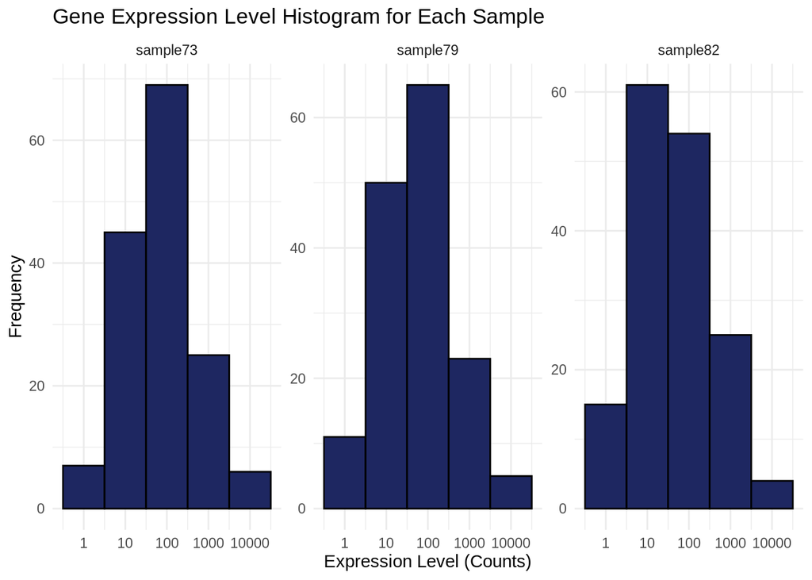

```r
# Melt the count matrix into long format
Peve_counts_siRNA_norm_melted <- melt(Peve_counts_siRNA_norm, variable.name = "sample", value.name = "counts")

# Plot the expression level histograms for each sample
ggplot(Peve_counts_siRNA_norm_melted, aes(x = counts)) +
  geom_histogram(binwidth = 1, fill = "#1E2761", color = "black") +
  scale_x_log10() +  # Optional: Log-transform the x-axis for better visualization
  facet_wrap(~sample, scales = "free_y") +
  labs(title = "Gene Expression Level Histogram for Each Sample",
       x = "Expression Level (Counts)",
       y = "Frequency") +
  theme_minimal()
```

## 7.3 Normalized transcript counts

Check the total number of transcripts in each sample – now that we’ve normalized the data these totals should be similar

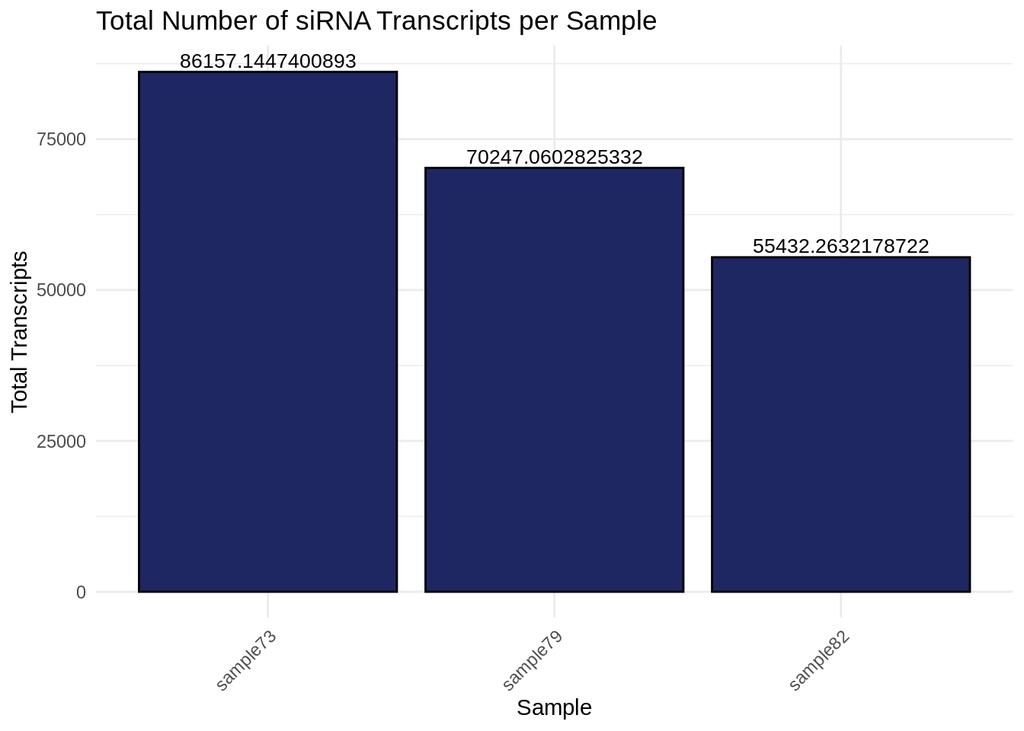

```r
# Calculate the total number of transcripts for each sample
total_transcripts_siRNA_norm <- colSums(Peve_counts_siRNA_norm)

# Create a data frame for plotting
total_transcripts_siRNA_norm_df <- data.frame(sample = names(total_transcripts_siRNA_norm),
                                   totals = total_transcripts_siRNA_norm)

# Plot the total number of transcripts for each sample
ggplot(total_transcripts_siRNA_norm_df, aes(x = sample, y = totals)) +
  geom_bar(stat = "identity", fill = "#1E2761", color = "black") +
  geom_text(aes(label = totals), vjust = -0.3, size = 3.5) +
  labs(title = "Total Number of siRNA Transcripts per Sample",
       x = "Sample",
       y = "Total Transcripts") +
  theme_minimal() +
  theme(axis.text.x = element_text(angle = 45, hjust = 1))  # Rotate x-axis labels for readability
```

## 7.4 Heatmap

Of all siRNAs

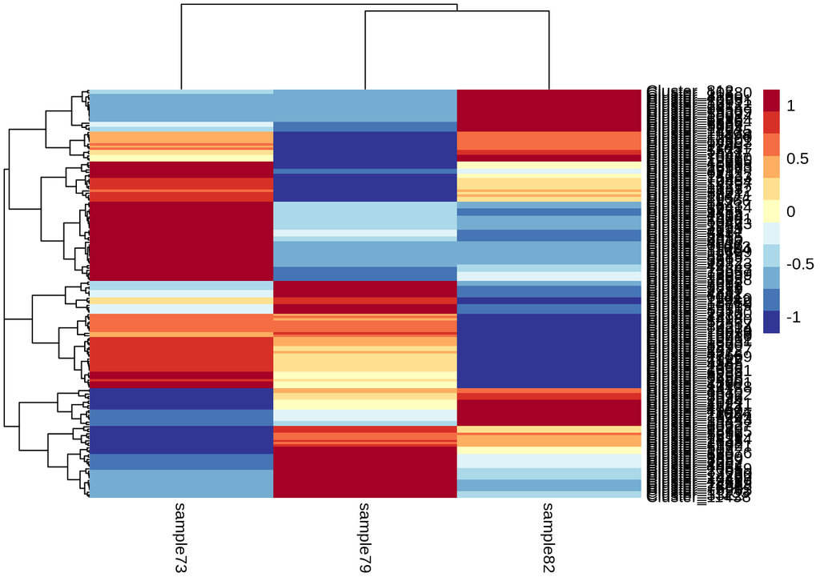

```r
heat_colors <- rev(brewer.pal(12, "RdYlBu"))
pheatmap(as.matrix(Peve_counts_siRNA_vsd[apply(Peve_counts_siRNA_vsd, 1, var) > 0, ]),
         cluster_rows = TRUE,
         cluster_cols = TRUE,
         show_rownames = TRUE,
         show_colnames = TRUE,
         color = heat_colors,
         scale="row")
```